# AFL: Player attribute influence on results

## Revisit: Purpose & Objective

**As coach, how can I build, select or train my AFL team to maximise success?** (game snippet: youtube.com/watch?v=QH188gSGnsk)

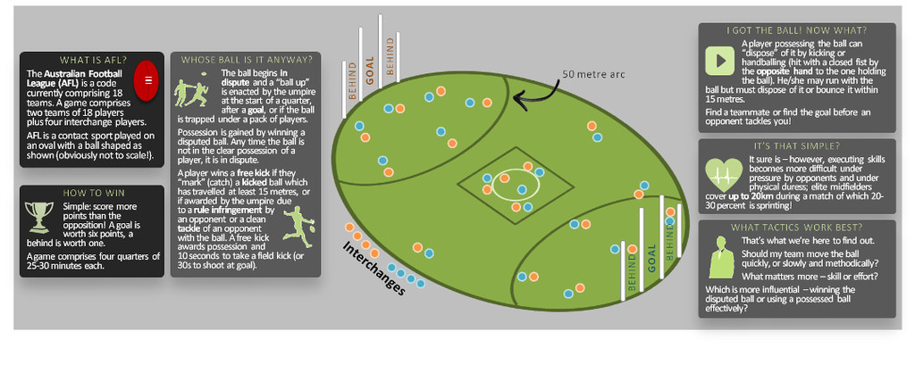

### Hypothesis

The core hypothesis of the analysis is that **AFL player performance data** recorded from competitive matches can be used to identify key success criteria and in turn **predict match results**.

## Data sources and key variables

Data for this project was collected from afltables.com as this site was easy and free to extract from compared to the official AFL or Champion Data sites.

### x variables

The player metrics are the x variables; that is, the hypothesis is the players' performance as aggregated at team level can explain and predict the match result. See example here (one team, one season, round-by-round): afltables.com/afl/stats/teams/geelong/2017_gbg.html

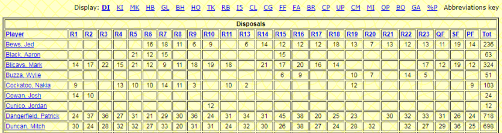

In total, I analysed 15 seasons worth of data for 16-18 teams (the number of teams has not been consistent over that timeframe). Due to the number of combinations of seasons and teams, I scraped this data with R.

## Data sources and key variables (cont'd)

### y variable

The metric I am seeking to predict is the team result for a given match. See example here (one season, round-by-round): afltables.com/afl/seas/2017.html

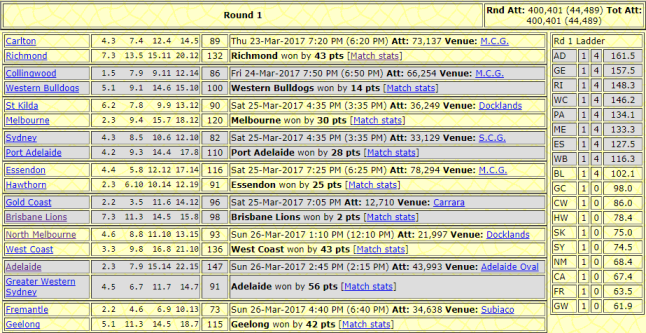

I analysed the same 15 seasons for the teams. This data was easy to copy manually and extract via Excel.

## Scraping player metrics

If we take the minimum number of 16 teams, multiplied by 15 seasons, there are at least 240 pages of data to copy, on top of which rules would be required to extract the data into fields.

Instead, I scraped the data six years at a time using html manipulation package **rvest**. The code is flexible enough to go back 50 or 100 years if desired.

### Environment set-up:

```r
#### CONSTANTS ####
  start.yr <- 2012
  end.yr <- 2017
  # Team aliases and start dates (allowing for teams with shorter histories)
    # Alias to be used in the analysis
    current.teams.alias <- c("Adelaide","Brisbane","Carlton","Collingwood","Essendon","Fremantle","Geelong",
                             "Gold Coast","Greater Western Sydney","Hawthorn","Melbourne","North Melbourne",
                             "Port Adelaide","Richmond","St Kilda","Sydney","West Coast","Western Bulldogs")
    # Alias for generating URLs to scrape data
    current.teams.url <- c("adelaide","brisbanel","carlton","collingwood","essendon","fremantle","geelong",
                           "goldcoast","gws","hawthorn","melbourne","kangaroos","padelaide","richmond","stkilda",
                           "swans","westcoast","bullldogs")
    # Start years for each team
    current.teams.start.yr <- c(1991,1997,1897,1897,1897,1995,1897,2011,2012,1925,1897,1925,1997,1908,1897,1897,1987,1925)
    # Round labels denoting finals games
    finals.rounds <- c("QF","EF","SF","PF","GF")

#### Load required libraries ####
library(rvest)
library(dplyr)
```

## Scraping player metrics (cont'd)

### Main function

This function opens the supplied URL in html, extracts the relevant headers and body and outputs an organised data frame.

```r
  # Open generated URL, extract data from html, return data frame
  player.scraper.exec <- function(in.url, in.alias, in.year){
    raw.html <- read_html(in.url)
    # Extract relevant tags into vectors
    data.headers <- raw.html %>% html_nodes(xpath="//thead//th") %>% html_text()
    data.body <- raw.html %>% html_nodes(xpath="//tbody//td") %>% html_text()
    # 1. Wrangle headers to understand the width of the data
      # Extract all the metrics headers by removing specific strings (Player, Round, Tot headings), e.g. Disposals, Kicks, etc
      stats.labels <- data.headers[!(
        grepl(pattern = "Player", data.headers) | grepl(pattern = "R[0-9]+", data.headers) | data.headers %in% c(finals.rounds,"Tot")
      )]
      # Removing these values will leave just the player and round headings, e.g. Player, R1, R2 etc for each game played
      stats.labels.rounds <- data.headers[!(data.headers %in% stats.labels)]
      # Get number of rounds the team played, this tells us how many columns to create in the data frame
      stats.rounds <- stats.labels.rounds[1:(length(stats.labels.rounds)/length(stats.labels))]
    # 2. Wrangle the actual metrics from the body of the data
      # Create data frame with correct number of columns for number of rounds played
      sync.df <- as.data.frame(matrix(data.body, ncol=length(stats.rounds), byrow = TRUE), stringsAsFactors = FALSE)
      colnames(sync.df) <- stats.rounds
    # 3. Add information to identify the rows later
      # Get the player names from the body, identifiable by the presence of a comma-space sequence in the string, e.g. Bews, Jed
      team.players <- unique(data.body[grepl(pattern = "*,\\s*", data.body)])
      # Add column with the metric being tracked, e.g. Disposals, Kicks, etc repeated for each player, for each round
      sync.df[,"Metric"] <- rep(stats.labels, each=length(team.players))
      # Add columns for team and year, e.g. Geelong, 2017
      sync.df[,"Team"] <- rep(in.alias, times=nrow(sync.df))
      sync.df[,"Year"] <- rep(in.year, times=nrow(sync.df))
    # Take a nap (R dislikes running html scraping in a loop too rapidly!)
    Sys.sleep(5)
    # 4. Return the prepared data frame to function call
    return(sync.df)
  }
```

## Scraping player metrics (cont'd)

### Other functions

These functions exist to run the main function smoothly: generating the URL parameter and simplifying the function call to use **lapply**, which improves code performance (rather than using nested **for** loops).

```r
  # URL generator
  player.scraper.url <- function(in.team, in.year){
    return(paste0("https://afltables.com/afl/stats/teams/", in.team, "/", in.year, "_gbg.html"))
  }

  # Simplify function call for LAPPLY
  player.scraper.exec.do <- function(i){
    # Print a line so we know where we're up to
    print(paste(Sys.time(), "Extracting player data for", par.alias[i], par.years[i]))
    # Call the URL extraction and return the generated data frame
    inner.df <- player.scraper.exec(player.scraper.url(par.teams[i], par.years[i]), par.alias[i], par.years[i])
    return(inner.df)
  }
```

## Scraping player metrics (cont'd)

### Execution

This code uses the defined functions to actually execute the scraping. First, three synchronised vectors are set up to dynamically generate the URLs and other relevant parameters (using nested **for** loops doesn't lose much performance in this context). Second, **lapply** is used to sequence through the vectors and extract the data into a list of data frames. Finally, the list of data frames is consolidated into one with the correct dimensions, using a **for** loop.

```r
#### Prepare for extraction ####
  # variables to hold URL generator parameters (team and year)
  par.years <- c()
  par.teams <- c()
  par.alias <- c()
  # for each year in scope
  for(y in seq(start.yr, end.yr, by=1)){
    # for each team, check if team had started by that year
    for(t in 1:length(current.teams.url)){
      if(current.teams.start.yr[t] <= y){
        par.years <- c(par.years, y)
        par.teams <- c(par.teams, current.teams.url[t])
        par.alias <- c(par.alias, current.teams.alias[t])
  } } }
  # end result is three equal length vectors with each year and each team to feed to URL generator

#### Load web pages and extract player data ####
  # create sequencing variable and extract to list of data frames
  x <- seq_along(par.teams)
  list.df <- lapply(x, FUN = player.scraper.exec.do)
  # consolidate in one data frame
    # prepare master data frame with all required columns, up to 24 rounds plus finals plus totals
    cons.headers = c("Player", paste0("R",seq(1,24,by=1)), finals.rounds, "Tot", "Metric", "Team", "Year")
    cons.df <- as.data.frame(matrix(ncol = length(cons.headers), nrow = 0), stringsAsFactors = FALSE)
    colnames(cons.df) <- cons.headers
    # populate data from list of data frames
    for(i in x){ cons.df <- union_all(cons.df, list.df[[i]]) }
```

## Data wrangling

### Player metrics

As the player metric data was scraped from html, it is structured well albeit as character strings. The data totals over 200K rows, showing a single player metric for every round. Due to volume of data, this R Markdown is filtered to the 2017 season only (~15K rows).

```r
  head(raw.player.metrics)
```

```
##             Player R1 R2 R3 R4 R5 R6 R7 R8 R9 R10 R11 R12  R13 R14 R15 R16 R17 R18 R19 R20 R21 R22 R23 R24 QF   EF   SF PF GF Tot    Metric     Team Year GF.1
## 1     Atkins, Rory 19 19 19 23 29 23 20 21 28  37  14  25 <NA>  28  15  23  18  19  16  16  27  21  21  NA 16 <NA> <NA> 22 17 536 Disposals Adelaide 2017   NA
## 2  Beech, Jonathon                                     15 <NA>  12  11                                  NA    <NA> <NA>        38 Disposals Adelaide 2017   NA
## 3     Betts, Eddie 18 13 16 22 12 16 13  9 16  14  12  11 <NA>  14  11  13  16   8      16   7  16  12  NA 13 <NA> <NA> 13  7 318 Disposals Adelaide 2017   NA
## 4      Brown, Luke 18 12 13  9 15 17 13 20 25  16  12     <NA>  10  15  14  17  11  10  20  17  17   9  NA 20 <NA> <NA> 10 13 353 Disposals Adelaide 2017   NA
## 5 Cameron, Charlie 23 17 16 16 13 13 14 10 18  13   8  13 <NA>  15      10  20   6   9  17  13  10  10  NA 15 <NA> <NA> 19 16 334 Disposals Adelaide 2017   NA
## 6     Crouch, Brad             33 26 24 26 29  30  28  24 <NA>  29  30  24  27  29      29  20  26  42  NA 27 <NA> <NA> 29 29 561 Disposals Adelaide 2017   NA
```

Wrangling was performed with **dplyr** and **tidyr** packages. The "Tot" (Total) column and "Subs" (Substitution) rows are not required as they don't provide meaningful data to analyse. The data was pivoted to a long format and non-ASCII characters removed. Metrics were converted to numeric, with NAs, blanks and dashes imputed as zeroes (confirmed by summing before and after in a spreadsheet).

```r
  player.metrics <- raw.player.metrics %>% select(-Tot) %>% filter(Metric != "Subs")
  # Turn data into long format, clean non-ASCII characters
  player.metrics <- player.metrics %>%
    gather(key = round, value = round_stat, -Player, -Metric, -Team, -Year) %>%
    mutate(round_stat = iconv(trimws(round_stat, "both"), to = "ASCII", sub = ""), round_stat = if_else(!is.na(round_stat) & !(round_stat %in% c("","-")), as.numeric(round_stat), 0))
  head(player.metrics)
```

```
##             Player    Metric     Team Year round round_stat
## 1     Atkins, Rory Disposals Adelaide 2017    R1         19
## 2  Beech, Jonathon Disposals Adelaide 2017    R1          0
## 3     Betts, Eddie Disposals Adelaide 2017    R1         18
## 4      Brown, Luke Disposals Adelaide 2017    R1         18
## 5 Cameron, Charlie Disposals Adelaide 2017    R1         23
## 6     Crouch, Brad Disposals Adelaide 2017    R1          0
```

## Data wrangling

### Player metrics (cont'd)

The Metric column was trimmed and the data was pivoted back to wide format, but this time showing columns for metrics and rows for rounds, which is a more logical way of considering the data (by game). Columns were renamed as needed to make them easier to reference.

```r
  player.metrics <- player.metrics %>% mutate(Metric = trimws(Metric, "both")) %>% spread(key = Metric, value = round_stat) %>%
  rename(Played_pct = `% Played`, Brownlow_votes = `Brownlow Votes`, Contested_marks = `Contested Marks`, Contested_possessions = `Contested Possessions`
           , Frees_against = `Frees Against`, Goal_assists = `Goal Assists`, Hit_outs = `Hit Outs`, Inside_50s = `Inside 50s`
           , Marks_inside_50 = `Marks Inside 50`, One_pct = `One Percenters`, Uncontested_possessions = `Uncontested Possessions`)

  head(player.metrics)
```

```
##         Player       Team Year round Played_pct Behinds Bounces Brownlow_votes Clangers Clearances Contested_marks Contested_possessions Disposals Frees Frees_against Goal_assists Goals Handballs
## 1 Ablett, Gary Gold Coast 2017    EF          0       0       0              0        0          0               0                     0         0     0             0            0     0         0
## 2 Ablett, Gary Gold Coast 2017    GF          0       0       0              0        0          0               0                     0         0     0             0            0     0         0
## 3 Ablett, Gary Gold Coast 2017  GF.1          0       0       0              0        0          0               0                     0         0     0             0            0     0         0
## 4 Ablett, Gary Gold Coast 2017    PF          0       0       0              0        0          0               0                     0         0     0             0            0     0         0
## 5 Ablett, Gary Gold Coast 2017    QF          0       0       0              0        0          0               0                     0         0     0             0            0     0         0
## 6 Ablett, Gary Gold Coast 2017    R1         82       0       0              0        4          5               0                    13        28     1             1            2     0        12
##   Hit_outs Inside_50s Kicks Marks Marks_inside_50 One_pct Rebounds Tackles Uncontested_possessions
## 1        0          0     0     0               0       0        0       0                       0
## 2        0          0     0     0               0       0        0       0                       0
## 3        0          0     0     0               0       0        0       0                       0
## 4        0          0     0     0               0       0        0       0                       0
## 5        0          0     0     0               0       0        0       0                       0
## 6        0         12    16     1               0       3        1       8                      15
```

Next, a check on players with zero game time - did they participate? With ~146K rows showing no game time and a sum of only 5 across **all** metrics, we can safely ignore these. The 5 can be explained by players who get injured in the first 60-90 seconds of a match and play no further part (note: the output below shows different results due to filtering out of data).

```r
  print(paste("Total players with zero game time:", nrow(player.metrics[player.metrics$Played_pct==0, ]),
      " Sum of all metrics for players with zero game time:", sum(player.metrics[player.metrics$Played_pct==0, 5:27])))
```

```
## [1] "Total players with zero game time: 10572  Sum of all metrics for players with zero game time: 0"
```

## Data wrangling

### Player metrics (cont'd)

So we filter out players with 0 Played_pct, and we remove non-meaningful metrics: Brownlow_votes (best & fairest voting) and Rebounds (not clear whether caused by defender skill or attacker mistake). Also adjusted the rounds so sorting alphabetically will sort them chronologically.

```r
  player.metrics <- player.metrics %>% filter(Played_pct > 0) %>% select(-Brownlow_votes, -Rebounds)

  player.metrics$round <- sub("R([0-9])$", "R0\\1", player.metrics$round)
  player.metrics$round <- sub("EF", "R25-EF", player.metrics$round, fixed = TRUE)
  player.metrics$round <- sub("QF", "R25-QF", player.metrics$round, fixed = TRUE)
  player.metrics$round <- sub("SF", "R26-SF", player.metrics$round, fixed = TRUE)
  player.metrics$round <- sub("PF", "R27-PF", player.metrics$round, fixed = TRUE)
  player.metrics$round <- sub("GF", "R28-GF", player.metrics$round, fixed = TRUE)
  player.metrics$round <- sub("GF.1", "R29-GF2", player.metrics$round, fixed = TRUE)
  player.metrics <- player.metrics %>% arrange(desc(Year), Team, round, Player)

  head(player.metrics)
```

```
##             Player     Team Year round Played_pct Behinds Bounces Clangers Clearances Contested_marks Contested_possessions Disposals Frees Frees_against Goal_assists Goals Handballs Hit_outs
## 1     Atkins, Rory Adelaide 2017   R01         82       0       4        2          1               0                     6        19     1             0            2     3         5        0
## 2     Betts, Eddie Adelaide 2017   R01         88       2       2        4          1               0                     4        18     2             3            2     4         4        0
## 3      Brown, Luke Adelaide 2017   R01         86       0       0        0          0               0                     7        18     2             0            0     0         9        0
## 4 Cameron, Charlie Adelaide 2017   R01         84       3       1        4          8               2                    14        23     1             1            0     2         6        0
## 5     Crouch, Matt Adelaide 2017   R01         78       0       1        3          4               0                    15        29     1             0            0     0        20        0
## 6 Douglas, Richard Adelaide 2017   R01         81       0       0        6          3               1                     8        27     1             2            2     2        11        0
##   Inside_50s Kicks Marks Marks_inside_50 One_pct Tackles Uncontested_possessions
## 1         10    14     5               1       0       7                      14
## 2          7    14     4               3       0       1                      14
## 3          1     9     4               0       5       3                      11
## 4          6    17     4               3       1       6                       9
## 5          2     9     3               0       2       5                      15
## 6          8    16     6               0       0       1                      18
```

At this point, the **player metric data is ready to use**.

## Data wrangling

### Team results

The team results needed to be extracted in Excel and arrive in a messy form in R. In addition to **dplyr** and **tidyr**, I also used the **xlsx** and **data.table** packages. There are over 5.5K rows but this R Markdown is filtered for 2017 only (~400 rows).

```r
  head(raw.team.res)
```

```
##              teams               score_str final_score                                                     match_summ   round home_away season
## 1          Carlton   4.3   7.4  12.4  14.5          89    Thu 23-Mar-2017 7:20 PM (6:20 PM) Att: 73,137 Venue: M.C.G. Round 1      home   2017
## 2         Richmond   7.3  13.5 15.11 20.12         132                           Richmond won by 43 pts [Match stats] Round 1      away   2017
## 3      Collingwood   1.5   7.9  9.11 12.14          86    Fri 24-Mar-2017 7:50 PM (6:50 PM) Att: 66,254 Venue: M.C.G. Round 1      home   2017
## 4 Western Bulldogs   5.1   9.1  14.6 15.10         100                   Western Bulldogs won by 14 pts [Match stats] Round 1      away   2017
## 5         St Kilda   6.2   7.8   9.9 13.12          90 Sat 25-Mar-2017 4:35 PM (3:35 PM) Att: 36,249 Venue: Docklands Round 1      home   2017
## 6        Melbourne   2.3   9.4  15.7 18.12         120                          Melbourne won by 30 pts [Match stats] Round 1      away   2017
```

The final scores are converted to integers, and at this point we need to define a function to parse the score string into quarter-end scores. These strings are currently formatted as cumulative *goals.behinds* for each quarter.

```r
raw.team.res$final_score <- as.integer(raw.team.res$final_score)

parse_score_str <- function(in.score.str){
  # remove white space and brackets
  in.score.str <- trimws(in.score.str, "both")
  in.score.str <- sub("\\(([0-9]+)\\.([0-9]+)\\)", "\\1\\.\\2", in.score.str)
  # split into quarter scores by space
  list.score.str <- strsplit(in.score.str, split = "\\s+")[[1]]
  return.str.cumul <- c()
  # loop through each score, turn score into a number, e.g. 4.2 (4 goals, 2 behinds)
  for (Qs in list.score.str){
    Qsnum_goals <- as.integer(sub("\\..*$", "", Qs))
    Qsnum_behinds <- as.integer(sub("^.*\\.", "", Qs))
    # add up scores by multiplying goals by 6 and behinds by 1, return string of quarter scores
    Qsttl <- Qsnum_goals*6 + Qsnum_behinds*1
    return.str.cumul <- paste(return.str.cumul, Qsttl)
  }
  return(trimws(return.str.cumul,"left")) }
```

## Data wrangling

### Team results (cont'd)

The data is ordered in pairs, where each pair is a single match result. To allow joining, create a match_id. With pairs, we can also add a win or loss result and final margin. At the same time, let's parse the score string into a string of numerical values we can interpret easily.

```r
  # Create a "match id" since every two rows is one match result, add basic row number
  prep.team.res <- cbind(raw.team.res, match_id = rep(seq(1001, 1000+nrow(raw.team.res)/2, by=1), each=2)) %>% mutate(rownum = row_number()) %>%
  # group by match and add vs_opponent, result, margin
  group_by(match_id) %>%
  mutate(vs_opponent = if_else(rownum == min(rownum), lead(teams, 1L), lag(teams, 1L))
         , team_result = if_else(final_score == max(final_score) & final_score == min(final_score), "draw", if_else(final_score == max(final_score), "win", "loss"))
         , final_margin = if_else(rownum == min(rownum), final_score - lead(final_score, 1L), final_score - lag(final_score, 1L))) %>%
  ungroup %>%
  # remove unnecessary match summary column and change score string to numerical scores
  select(-match_summ) %>% rowwise %>% mutate(score_str = parse_score_str(score_str)) %>% ungroup

  head(prep.team.res)
```

```
## # A tibble: 6 x 11
##              teams     score_str final_score   round home_away season match_id rownum      vs_opponent team_result final_margin
##              <chr>         <chr>       <int>   <chr>     <chr>  <chr>    <dbl>  <int>            <chr>       <chr>        <int>
## 1          Carlton   27 46 76 89          89 Round 1      home   2017     1001      1         Richmond        loss          -43
## 2         Richmond 45 83 101 132         132 Round 1      away   2017     1001      2          Carlton         win           43
## 3      Collingwood   11 51 65 86          86 Round 1      home   2017     1002      3 Western Bulldogs        loss          -14
## 4 Western Bulldogs  31 55 90 100         100 Round 1      away   2017     1002      4      Collingwood         win           14
## 5         St Kilda   38 50 63 90          90 Round 1      home   2017     1003      5        Melbourne        loss          -30
## 6        Melbourne  15 58 97 120         120 Round 1      away   2017     1003      6         St Kilda         win           30
```

## Data wrangling

### Team results (cont'd)

Now let's parse out the quarter-end scores. I am unsure whether these will actually be used at this stage.

```r
# get list of the score strings
  score.str.list <- lapply(prep.team.res$score_str, function (x) strsplit(as.character(x), split="\\s")[[1]])
  # prepare columns for the cumulative quarter scores
  prep.team.res$Q1score_cumul <- 0
  prep.team.res$Q2score_cumul <- 0
  prep.team.res$Q3score_cumul <- 0
  prep.team.res$Q4score_cumul <- 0
  prep.team.res$ETscore_cumul <- 0
  # extract the quarter scores from the list, add to the data frame, adjust for the "fifth quarter" (extra time)
  for(i in 1:nrow(prep.team.res)){
    prep.team.res$Q1score_cumul[i] = as.integer(score.str.list[[i]][1])
    prep.team.res$Q2score_cumul[i] = as.integer(score.str.list[[i]][2])
    prep.team.res$Q3score_cumul[i] = as.integer(score.str.list[[i]][3])
    prep.team.res$Q4score_cumul[i] = as.integer(score.str.list[[i]][4])
    prep.team.res$ETscore_cumul[i] = if_else(!is.na(score.str.list[[i]][5]), as.integer(score.str.list[[i]][5]), NULL) }
  # calculate the non-cumulative quarter scores and add to the data frame
  prep.team.res <- prep.team.res %>%
    mutate(Q1score = Q1score_cumul, Q2score = Q2score_cumul - Q1score_cumul, Q3score = Q3score_cumul - Q2score_cumul
           , Q4score = Q4score_cumul - Q3score_cumul, ETscore = ETscore_cumul - Q4score_cumul) %>%
    group_by(match_id) %>%
    # add a flag to indicate whether the team won the quarter, drawn quarter is won by no one so is 0 for both teams
    mutate(Q1_win = if_else(Q1score == min(Q1score), 0, 1), Q2_win = if_else(Q2score == min(Q2score), 0, 1), Q3_win = if_else(Q3score == min(Q3score), 0, 1)
           , Q4_win = if_else(Q4score == min(Q4score), 0, 1), ET_win = if_else(ETscore == min(ETscore), 0, 1))

  head(data.frame(prep.team.res), 4)
```

```
##              teams     score_str final_score   round home_away season match_id rownum      vs_opponent team_result final_margin Q1score_cumul Q2score_cumul Q3score_cumul Q4score_cumul ETscore_cumul
## 1          Carlton   27 46 76 89          89 Round 1      home   2017     1001      1         Richmond        loss          -43            27            46            76            89            NA
## 2         Richmond 45 83 101 132         132 Round 1      away   2017     1001      2          Carlton         win           43            45            83           101           132            NA
## 3      Collingwood   11 51 65 86          86 Round 1      home   2017     1002      3 Western Bulldogs        loss          -14            11            51            65            86            NA
## 4 Western Bulldogs  31 55 90 100         100 Round 1      away   2017     1002      4      Collingwood         win           14            31            55            90           100            NA
##   Q1score Q2score Q3score Q4score ETscore Q1_win Q2_win Q3_win Q4_win ET_win
## 1      27      19      30      13      NA      0      0      1      0     NA
## 2      45      38      18      31      NA      1      1      0      1     NA
## 3      11      40      14      21      NA      0      1      0      1     NA
## 4      31      24      35      10      NA      1      0      1      0     NA
```

## Data wrangling

### Team results (cont'd)

Finally, wrangling to get terms and formats consistent with player metric data which will facilitate easy joining.

```r
  # adjustments to round
  prep.team.res$round <- sub("Round\\s(.*)$", "R\\1", prep.team.res$round)
  prep.team.res[which(prep.team.res$round=="Elimination Final"), "round"] <- "EF"
  prep.team.res[which(prep.team.res$round=="Qualifying Final"), "round"] <- "QF"
  prep.team.res[which(prep.team.res$round=="Semi Final"), "round"] <- "SF"
  prep.team.res[which(prep.team.res$round=="Preliminary Final"), "round"] <- "PF"
  prep.team.res[which(prep.team.res$round=="Grand Final"), "round"] <- "GF"
  # adjustments to data type
  prep.team.res$season <- as.numeric(prep.team.res$season)
  # column rename and fix inconsistent team names
  prep.team.res <- prep.team.res %>% rename(Year = season, Team = teams)
  prep.team.res$Team <- sub("Brisbane Lions", "Brisbane", prep.team.res$Team, fixed = TRUE)
  prep.team.res$Team <- sub("Kangaroos", "North Melbourne", prep.team.res$Team, fixed = TRUE)
  prep.team.res$vs_opponent <- sub("Brisbane Lions", "Brisbane", prep.team.res$vs_opponent, fixed = TRUE)
  prep.team.res$vs_opponent <- sub("Kangaroos", "North Melbourne", prep.team.res$vs_opponent, fixed = TRUE)

  head(data.frame(prep.team.res), 6)
```

```
##               Team     score_str final_score round home_away Year match_id rownum      vs_opponent team_result final_margin Q1score_cumul Q2score_cumul Q3score_cumul Q4score_cumul ETscore_cumul
## 1          Carlton   27 46 76 89          89    R1      home 2017     1001      1         Richmond        loss          -43            27            46            76            89            NA
## 2         Richmond 45 83 101 132         132    R1      away 2017     1001      2          Carlton         win           43            45            83           101           132            NA
## 3      Collingwood   11 51 65 86          86    R1      home 2017     1002      3 Western Bulldogs        loss          -14            11            51            65            86            NA
## 4 Western Bulldogs  31 55 90 100         100    R1      away 2017     1002      4      Collingwood         win           14            31            55            90           100            NA
## 5         St Kilda   38 50 63 90          90    R1      home 2017     1003      5        Melbourne        loss          -30            38            50            63            90            NA
## 6        Melbourne  15 58 97 120         120    R1      away 2017     1003      6         St Kilda         win           30            15            58            97           120            NA
##   Q1score Q2score Q3score Q4score ETscore Q1_win Q2_win Q3_win Q4_win ET_win
## 1      27      19      30      13      NA      0      0      1      0     NA
## 2      45      38      18      31      NA      1      1      0      1     NA
## 3      11      40      14      21      NA      0      1      0      1     NA
## 4      31      24      35      10      NA      1      0      1      0     NA
## 5      38      12      13      27      NA      1      0      0      1     NA
## 6      15      43      39      23      NA      0      1      1      0     NA
```

At this point, the **team results data is ready to use**.